# Covid Cases

2022-10-10

## Import Data and Packages

First import the required packages.

```r
library("tidyverse")
library("lubridate")
```

The COVID19 data is imported from the Johns Hopkins github site: https://github.com/CSSEGISandData/COVID-19/tree/master/csse_covid_19_data This data contains information about the number of confirmed cases and the number of deaths from the Covid-19 virus. We will clean and tidy the data and use it to inspect the data from different countries and regions to track the changes over time. The question we will try to answer is which US state or states have the highest death to cases ratio and why that may be.

```r
url <- 'https://raw.githubusercontent.com/CSSEGISandData/COVID-19/master/csse_covid_19_data/'
path <- 'csse_covid_19_time_series/'
file_names <- c('time_series_covid19_confirmed_global.csv',
                'time_series_covid19_deaths_global.csv',
                'time_series_covid19_confirmed_US.csv',
                'time_series_covid19_deaths_US.csv')
urls <- str_c(path, file_names)

global_cases <- read_csv(urls[1])
global_deaths <- read_csv(urls[2])
US_cases <- read_csv(urls[3])
US_deaths <- read_csv(urls[4])
```

First we combine the US cases and deaths into a single dataframe.

```r
US_cases <- US_cases %>%
  pivot_longer(cols = -(UID:Combined_Key),
               names_to = "date",
               values_to = "cases") %>%
  select(Admin2:cases) %>%
  mutate(date = mdy(date)) %>%
  select(-c(Lat, Long_))

US_deaths <- US_deaths %>%
  pivot_longer(cols = -(UID:Population),
               names_to = "date",
               values_to = "deaths") %>%
  select(Admin2:deaths) %>%
  mutate(date = mdy(date)) %>%
  select(-c(Lat, Long_))

US <- US_cases %>%
    full_join(US_deaths)
```

[output not shown]

Next we will break up the US dataset, group all the rows for each state, and add a new field to track the deaths per case ratio.

```r
US_by_state <- US %>%
  group_by(Province_State, Country_Region, date) %>%
  summarize(cases = sum(cases), deaths = sum(deaths),
            Population = sum(Population)) %>%
  mutate(deaths_per_case = deaths / cases) %>%
  select(Province_State, Country_Region, date,
         cases, deaths, deaths_per_case, Population) %>%
  ungroup()
```

Finally we combine it again to create a single dataframe for the whole US.

```r
US_totals <- US_by_state %>%
  group_by(Country_Region, date) %>%
  summarize(cases = sum(cases), deaths = sum(deaths),
            Population = sum(Population)) %>%
  mutate(deaths_per_case = deaths / cases) %>%
  select(Country_Region, date,
         cases, deaths, deaths_per_case, Population) %>%
  ungroup()
```

## Visualize Data

First we will visualize the total cases and total deaths to make sure our data is not corrupt.

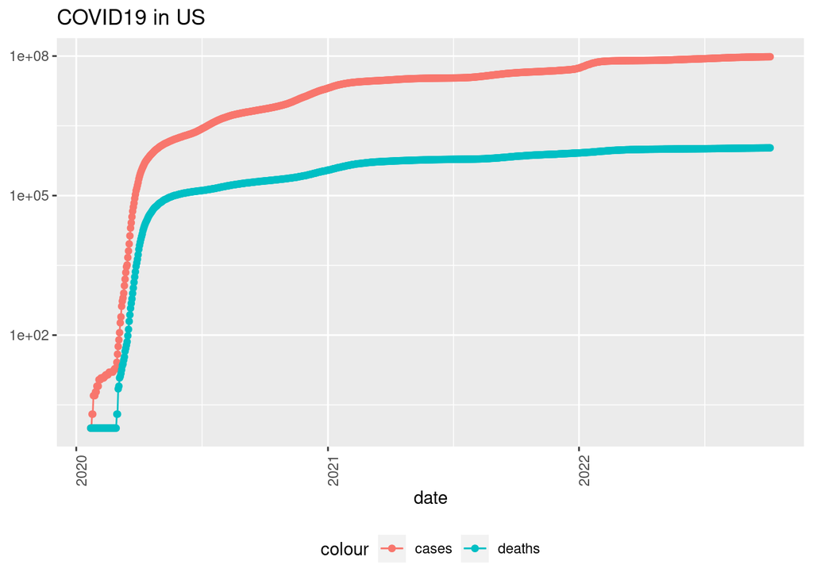

```r
US_totals %>%
  filter(cases > 0) %>%
  ggplot(aes(x = date, y = cases)) +
  geom_line(aes(color = "cases")) +
  geom_point(aes(color = "cases")) +
  geom_line(aes(y = deaths, color = "deaths")) +
  geom_point(aes(y = deaths, color = "deaths")) +
  scale_y_log10() +
  theme(legend.position = "bottom",
        axis.text.x = element_text(angle = 90)) +
  labs(title = "COVID19 in US", y = NULL)
```

We see that the deaths is tracking the cases as we would expect. Now lets visualize the ratio of deaths per case in the US.

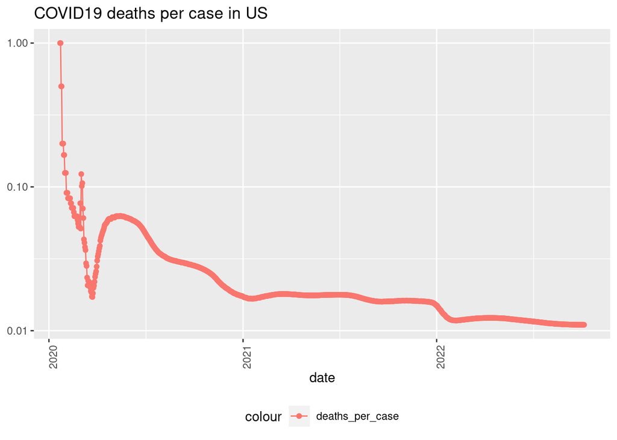

```r
US_totals %>%
  filter(cases > 0) %>%
  ggplot(aes(x = date, y = deaths_per_case)) +
  geom_line(aes(color = "deaths_per_case")) +
  geom_point(aes(color = "deaths_per_case")) +
  scale_y_log10() +
  theme(legend.position = "bottom",
        axis.text.x = element_text(angle = 90)) +
  labs(title = "COVID19 deaths per case in US", y = NULL)
```

## Analyze Data

Now, to inspect the deaths per case for each state, we will print a summary of the top five states before taking a closer look.

```r
US_by_state_totals <- US_by_state %>%
  filter(cases > 0) %>%
  group_by(Province_State) %>%
  summarize(cases = sum(cases), deaths = sum(deaths)) %>%
  mutate(deaths_per_case_totals = deaths / cases) %>%
  select(Province_State, cases, deaths, deaths_per_case_totals) %>%
  arrange(deaths_per_case_totals) %>%
  ungroup()

tail(US_by_state_totals)
```

```
## # A tibble: 6 × 4
##   Province_State      cases   deaths deaths_per_case_totals
##   <chr>               <dbl>    <dbl>                  <dbl>
## 1 Mississippi     384343502  6894121                 0.0179
## 2 Pennsylvania   1313145142 24394350                 0.0186
## 3 New York       2390144415 46597285                 0.0195
## 4 Connecticut     362549218  7102306                 0.0196
## 5 New Jersey     1089080214 22650176                 0.0208
## 6 Grand Princess      95369     2747                 0.0288
```

From this table we see that out of the 50 US states, New Jersey, Connecticut, and New York have the highest death per case ratios over the entire sampling period. We can plot each of their graphs to view the rate changes over time.

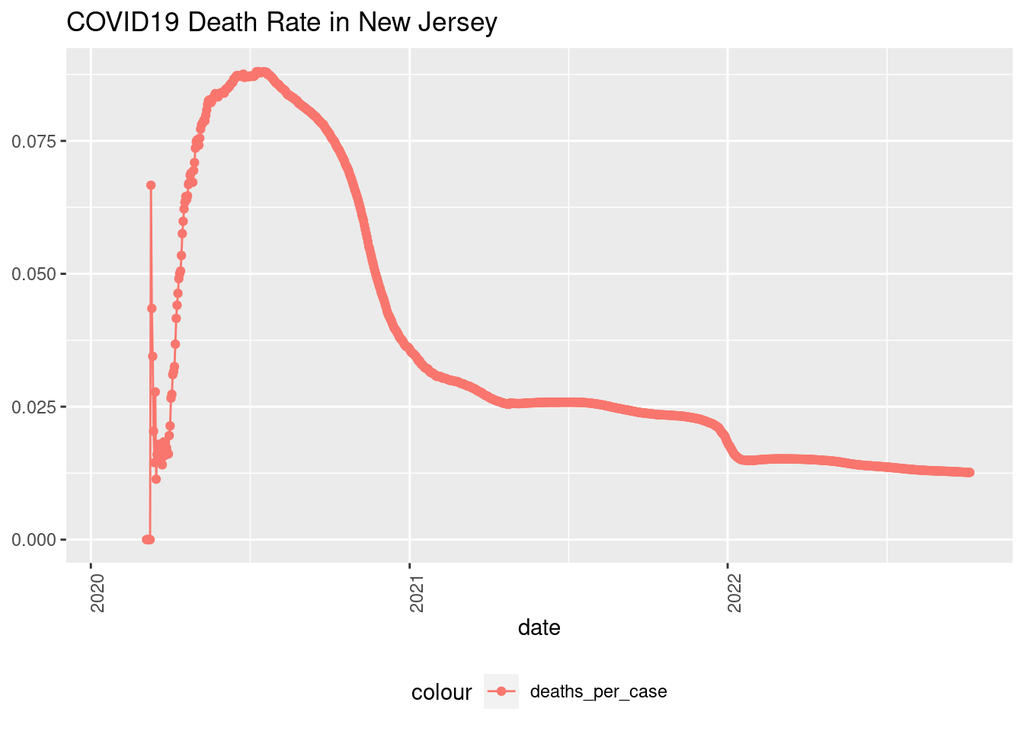

```r
state <- "New Jersey"
US_by_state %>%
  filter(Province_State == state) %>%
  ggplot(aes(x = date, y = deaths_per_case)) +
  geom_line(aes(color = "deaths_per_case")) +
  geom_point(aes(color = "deaths_per_case")) +
  theme(legend.position = "bottom",
        axis.text.x = element_text(angle = 90)) +
  labs(title = str_c("COVID19 Death Rate in ", state), y = NULL)
```

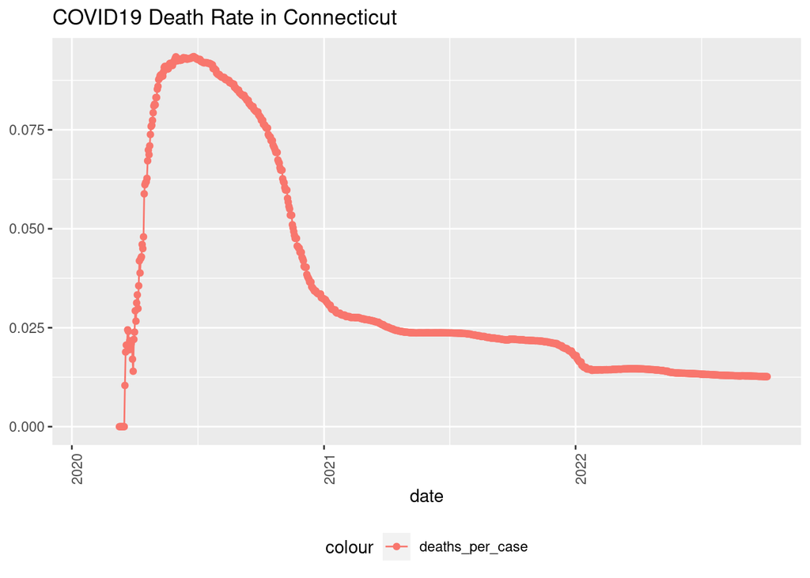

```r
state <- "Connecticut"
US_by_state %>%
  filter(Province_State == state) %>%
  ggplot(aes(x = date, y = deaths_per_case)) +
  geom_line(aes(color = "deaths_per_case")) +
  geom_point(aes(color = "deaths_per_case")) +
  theme(legend.position = "bottom",
        axis.text.x = element_text(angle = 90)) +
  labs(title = str_c("COVID19 Death Rate in ", state), y = NULL)
```

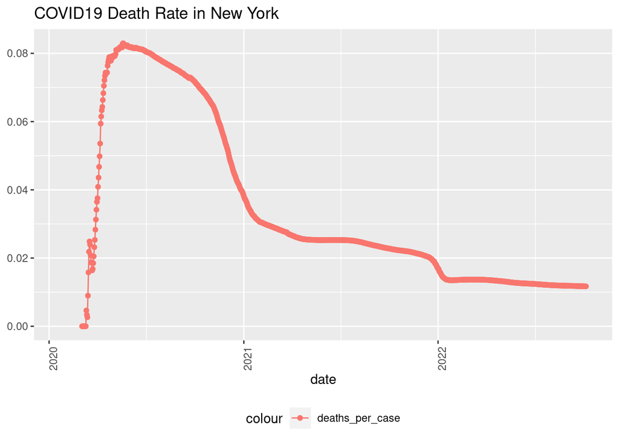

```r
state <- "New York"
US_by_state %>%
  filter(Province_State == state) %>%
  ggplot(aes(x = date, y = deaths_per_case)) +
  geom_line(aes(color = "deaths_per_case")) +
  geom_point(aes(color = "deaths_per_case")) +
  theme(legend.position = "bottom",
        axis.text.x = element_text(angle = 90)) +
  labs(title = str_c("COVID19 Death Rate in ", state), y = NULL)
```

These charts all show a significant drop off over the entire period but they also show a large hump occuring shortly after the outbreak started in early 2020. By contrast, lets look at a graph from the state with the lowest deaths per case and compare them. We find the lowest state by sorting the state totals dataframe.

```r
US_by_state_totals %>% arrange(deaths_per_case_totals)
```

```
## # A tibble: 58 × 4
##    Province_State               cases  deaths deaths_per_case_totals
##    <chr>                        <dbl>   <dbl>                  <dbl>
##  1 Diamond Princess             45760       0                0
##  2 Northern Mariana Islands   3097568   10606                0.00342
##  3 American Samoa             1333232    5568                0.00418
##  4 Alaska                   106514201  529137                0.00497
##  5 Utah                     446254317 2324903                0.00521
##  6 Vermont                   45220366  295749                0.00654
##  7 Hawaii                    96828102  651837                0.00673
##  8 Virgin Islands             7068877   51621                0.00730
##  9 Nebraska                 234986104 2172012                0.00924
## 10 Guam                      17955469  169586                0.00944
## # … with 48 more rows
```

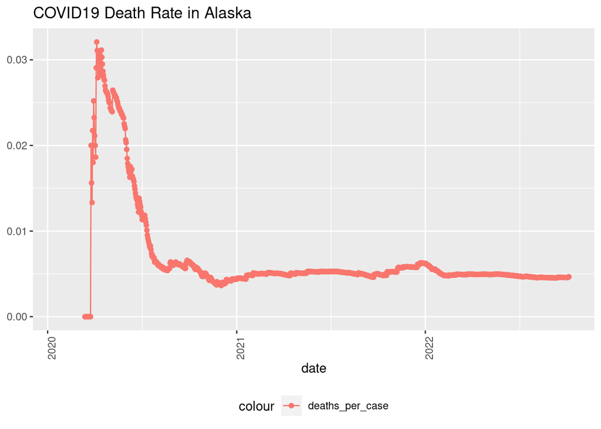

```r
state <- "Alaska"
US_by_state %>%
  filter(Province_State == state) %>%
  ggplot(aes(x = date, y = deaths_per_case)) +
  geom_line(aes(color = "deaths_per_case")) +
  geom_point(aes(color = "deaths_per_case")) +
  theme(legend.position = "bottom",
        axis.text.x = element_text(angle = 90)) +
  labs(title = str_c("COVID19 Death Rate in ", state), y = NULL)
```

Since Alaska has the lowest death per case ratio, we graph it and see that it has a much shorter recovery time. There is still a spike in the beginning but instead of looking like a hump, it comes down much more quickly.

## Modeling

In order to model this data, we will try to make a correlation between the total number of cases and the death ratio. The theory is that the more cases there are, the greater the death ratio will be. First we create the model.

```r
mod <- lm(cases ~ deaths_per_case_totals, data = US_by_state_totals)
summary(mod)
```

```
##
## Call:
## lm(formula = cases ~ deaths_per_case_totals, data = US_by_state_totals)
##
## Residuals:
##        Min         1Q     Median         3Q        Max
## -1.354e+09 -4.192e+08 -2.529e+08  1.181e+08  3.751e+09
##
## Coefficients:
##                         Estimate Std. Error t value Pr(>|t|)
## (Intercept)            1.093e+08  3.092e+08   0.353   0.7251
## deaths_per_case_totals 4.322e+10  2.271e+10   1.903   0.0622 .
## ---
## Signif. codes:  0 '***' 0.001 '**' 0.01 '*' 0.05 '.' 0.1 ' ' 1
##
## Residual standard error: 811300000 on 56 degrees of freedom
## Multiple R-squared:  0.06075,    Adjusted R-squared:  0.04398
## F-statistic: 3.622 on 1 and 56 DF,  p-value: 0.06216
```

```r
US_tot_w_pred <- US_by_state_totals %>% mutate(pred = predict(mod))
US_tot_w_pred
```

```
## # A tibble: 58 × 5
##    Province_State               cases  deaths deaths_per_case_totals       pred
##    <chr>                        <dbl>   <dbl>                  <dbl>      <dbl>
##  1 Diamond Princess             45760       0                0       109301539.
##  2 Northern Mariana Islands   3097568   10606                0.00342 257298245.
##  3 American Samoa             1333232    5568                0.00418 289817153.
##  4 Alaska                   106514201  529137                0.00497 324026183.
##  5 Utah                     446254317 2324903                0.00521 334488730.
##  6 Vermont                   45220366  295749                0.00654 391991566.
##  7 Hawaii                    96828102  651837                0.00673 400278675.
##  8 Virgin Islands             7068877   51621                0.00730 424945339.
##  9 Nebraska                 234986104 2172012                0.00924 508824105.
## 10 Guam                      17955469  169586                0.00944 517540564.
## # … with 48 more rows
```

The next step is to graph this model in red alongside the actual data in blue to see how well it does.

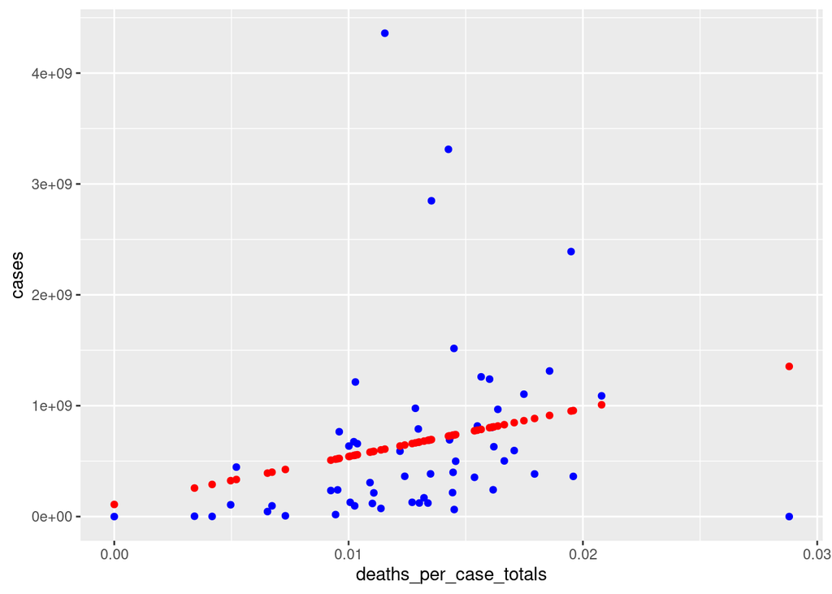

```r
US_tot_w_pred %>% ggplot() +
  geom_point(aes(x = deaths_per_case_totals, y = cases), color = "blue") +
  geom_point(aes(x = deaths_per_case_totals, y = pred), color = "red")
```